# Reproducible Research Project 2-Wk4

"Dr-A-Soni

19/02/2020

## **Synopsis**

The assignment is based on the U.S. National Oceanic and Atmospheric Administration’s (NOAA) storm database and it covers the Storms and other severe weather events spanning from 1950 to November 2011 that causes both public health and economic problems for communities and municipalities. This database tracks the characteristics of major storms and weather events in the United States, including when and where they occur, as well as estimates the fatalities, injuries, and Economic damage.

Storm Data: https://d396qusza40orc.cloudfront.net/repdata%2Fdata%2FStormData.csv.bz2

Additional Information include:

1. National Weather Service Storm Data Documentation- https://d396qusza40orc.cloudfront.net/repdata%2Fpeer2_doc%2Fpd01016005curr.pdf
2. National Climatic Data Center Storm Events FAQ - https://d396qusza40orc.cloudfront.net/repdata%2Fpeer2_doc%2FNCDC%20Storm%20Events-FAQ%20Page.pdf

This project addresses the following questions with relevant answer and supoorted evidence in terms of plots: 1)Across the United States, which types of events (as indicated in the EVTYPE EVTYPE variable) are most harmful with respect to population health? 2) Across the United States, which types of events have the greatest economic consequences?

### **Goal:**

#### The Goal of this addignment is to :

1. to learn to generate RMarkdown document
2. to know the importance of reproducibility
3. to analyse the data and produce answers for the given questions.

## **Data Processing**

```r
## Firstly set Working directory to the designated folder.
getwd()
```

```
## [1] "C:/Users/chinks/Downloads/coursera/wk4"
```

```r
setwd("c://Users/chinks/Downloads/coursera/wk4/")
getwd()
```

```
## [1] "c:/Users/chinks/Downloads/coursera/wk4"
```

```r
## Loading and processing the data from the raw file :

Storm <- read.csv("C://Users/chinks/Downloads/coursera/wk4/repdata_data_StormData(1).csv")
head(Storm)
```

```
##   STATE__           BGN_DATE BGN_TIME TIME_ZONE COUNTY COUNTYNAME STATE  EVTYPE
## 1       1  4/18/1950 0:00:00     0130       CST     97     MOBILE    AL TORNADO
## 2       1  4/18/1950 0:00:00     0145       CST      3    BALDWIN    AL TORNADO
## 3       1  2/20/1951 0:00:00     1600       CST     57    FAYETTE    AL TORNADO
## 4       1   6/8/1951 0:00:00     0900       CST     89    MADISON    AL TORNADO
## 5       1 11/15/1951 0:00:00     1500       CST     43    CULLMAN    AL TORNADO
## 6       1 11/15/1951 0:00:00     2000       CST     77 LAUDERDALE    AL TORNADO
##   BGN_RANGE BGN_AZI BGN_LOCATI END_DATE END_TIME COUNTY_END COUNTYENDN
## 1         0                                               0         NA
## 2         0                                               0         NA
## 3         0                                               0         NA
## 4         0                                               0         NA
## 5         0                                               0         NA
## 6         0                                               0         NA
##   END_RANGE END_AZI END_LOCATI LENGTH WIDTH F MAG FATALITIES INJURIES PROPDMG
```

[output cut: 20 more lines]

```r
colnames(Storm)
```

```
##  [1] "STATE__"    "BGN_DATE"   "BGN_TIME"   "TIME_ZONE"  "COUNTY"
##  [6] "COUNTYNAME" "STATE"      "EVTYPE"     "BGN_RANGE"  "BGN_AZI"
## [11] "BGN_LOCATI" "END_DATE"   "END_TIME"   "COUNTY_END" "COUNTYENDN"
## [16] "END_RANGE"  "END_AZI"    "END_LOCATI" "LENGTH"     "WIDTH"
## [21] "F"          "MAG"        "FATALITIES" "INJURIES"   "PROPDMG"
## [26] "PROPDMGEXP" "CROPDMG"    "CROPDMGEXP" "WFO"        "STATEOFFIC"
## [31] "ZONENAMES"  "LATITUDE"   "LONGITUDE"  "LATITUDE_E" "LONGITUDE_"
## [36] "REMARKS"    "REFNUM"
```

```r
summary(Storm)
```

[output not shown]

[output cut: 41 more lines]

```
##  Min.   :   0   Min.   :-14451   Min.   :   0   Min.   :-14455
##  1st Qu.:2802   1st Qu.:  7247   1st Qu.:   0   1st Qu.:     0
##  Median :3540   Median :  8707   Median :   0   Median :     0
##  Mean   :2875   Mean   :  6940   Mean   :1452   Mean   :  3509
##  3rd Qu.:4019   3rd Qu.:  9605   3rd Qu.:3549   3rd Qu.:  8735
##  Max.   :9706   Max.   : 17124   Max.   :9706   Max.   :106220
##  NA's   :47                      NA's   :40
##                                            REMARKS           REFNUM
##                                                :287433   Min.   :     1
##                                                : 24013   1st Qu.:225575
##  Trees down.\n                                 :  1110   Median :451149
##  Several trees were blown down.\n              :   569   Mean   :451149
##  Trees were downed.\n                          :   446   3rd Qu.:676723
##  Large trees and power lines were blown down.\n:   432   Max.   :902297
##  (Other)                                       :588294
```

## Loading relevant packages

```r
library(dplyr)
```

```r
library(ggplot2)
```

## **To answer the question not all the data is relevant, hence narrowing down the data with the informaiton improtant to answer to question.**

```r
Storm_Health <- Storm[ , c(8,23:24)]
##Our new data set includes:
## i)Event Types (EVTYPE)
## ii)Fatalities
### iii)Injuries

head(Storm_Health)
```

```
##    EVTYPE FATALITIES INJURIES
## 1 TORNADO          0       15
## 2 TORNADO          0        0
## 3 TORNADO          0        2
## 4 TORNADO          0        2
## 5 TORNADO          0        2
## 6 TORNADO          0        6
```

```r
dim(Storm_Health)
```

```
## [1] 902297      3
```

```r
summary(Storm_Health)
```

```
##                EVTYPE         FATALITIES          INJURIES
##  HAIL             :288661   Min.   :  0.0000   Min.   :   0.0000
##  TSTM WIND        :219940   1st Qu.:  0.0000   1st Qu.:   0.0000
##  THUNDERSTORM WIND: 82563   Median :  0.0000   Median :   0.0000
##  TORNADO          : 60652   Mean   :  0.0168   Mean   :   0.1557
##  FLASH FLOOD      : 54277   3rd Qu.:  0.0000   3rd Qu.:   0.0000
##  FLOOD            : 25326   Max.   :583.0000   Max.   :1700.0000
##  (Other)          :170878
```

### Part 1 : Addressing Individually the Fatalities and Injuries resulting from the Storm Events:

```r
## Aggregating the data of Fatalities into a new vector
Fatal <- aggregate(FATALITIES ~ EVTYPE, data = Storm_Health, sum)
head(Fatal)
```

```
##                  EVTYPE FATALITIES
## 1    HIGH SURF ADVISORY          0
## 2         COASTAL FLOOD          0
## 3           FLASH FLOOD          0
## 4             LIGHTNING          0
## 5             TSTM WIND          0
## 6       TSTM WIND (G45)          0
```

```r
## arranging the data with highest fatalities,
Fatal <- Fatal[order(Fatal$FATALITIES, decreasing = TRUE), ]
head(Fatal, 10)
```

```
##             EVTYPE FATALITIES
## 834        TORNADO       5633
## 130 EXCESSIVE HEAT       1903
## 153    FLASH FLOOD        978
## 275           HEAT        937
## 464      LIGHTNING        816
## 856      TSTM WIND        504
## 170          FLOOD        470
## 585    RIP CURRENT        368
## 359      HIGH WIND        248
## 19       AVALANCHE        224
```

```r
Storm_Fatal <- Fatal[1:10, ]
Storm_Fatal
```

```
##             EVTYPE FATALITIES
## 834        TORNADO       5633
## 130 EXCESSIVE HEAT       1903
## 153    FLASH FLOOD        978
## 275           HEAT        937
## 464      LIGHTNING        816
## 856      TSTM WIND        504
## 170          FLOOD        470
## 585    RIP CURRENT        368
## 359      HIGH WIND        248
## 19       AVALANCHE        224
```

```r
## Aggregating the data of Injuries into a new vector:
Injuries <- aggregate(INJURIES ~ EVTYPE, data = Storm_Health, sum)
head(Injuries)
```

```
##                  EVTYPE INJURIES
## 1    HIGH SURF ADVISORY        0
## 2         COASTAL FLOOD        0
## 3           FLASH FLOOD        0
## 4             LIGHTNING        0
## 5             TSTM WIND        0
## 6       TSTM WIND (G45)        0
```

```r
## sorting the data with the highest injuries.
Injuries <- Injuries[order(-Injuries$INJURIES), ]
## Using the Top 10 results
Storm_Injury <- Injuries[1:10, ]
Storm_Injury
```

```
##                EVTYPE INJURIES
## 834           TORNADO    91346
## 856         TSTM WIND     6957
## 170             FLOOD     6789
## 130    EXCESSIVE HEAT     6525
## 464         LIGHTNING     5230
## 275              HEAT     2100
## 427         ICE STORM     1975
## 153       FLASH FLOOD     1777
## 760 THUNDERSTORM WIND     1488
## 244              HAIL     1361
```

### Part 2: Using Combined numbers: Answering the question by combining the effects of the events:

```r
HEalth_Outcome <- aggregate(cbind(FATALITIES, INJURIES) ~ EVTYPE, data = Storm_Health, FUN = sum)
HEalth_Outcome$People_Loss <- HEalth_Outcome$FATALITIES + HEalth_Outcome$INJURIES
head(HEalth_Outcome)
```

```
##                  EVTYPE FATALITIES INJURIES People_Loss
## 1    HIGH SURF ADVISORY          0        0           0
## 2         COASTAL FLOOD          0        0           0
## 3           FLASH FLOOD          0        0           0
## 4             LIGHTNING          0        0           0
## 5             TSTM WIND          0        0           0
## 6       TSTM WIND (G45)          0        0           0
```

```r
### re-arranging the data
HEalth_Outcome <- HEalth_Outcome[order(HEalth_Outcome$People_Loss, decreasing = TRUE), ]
head(HEalth_Outcome)
```

```
##             EVTYPE FATALITIES INJURIES People_Loss
## 834        TORNADO       5633    91346       96979
## 130 EXCESSIVE HEAT       1903     6525        8428
## 856      TSTM WIND        504     6957        7461
## 170          FLOOD        470     6789        7259
## 464      LIGHTNING        816     5230        6046
## 275           HEAT        937     2100        3037
```

```r
Casualty <- HEalth_Outcome[1:10, ]
colnames(Casualty)
```

```
## [1] "EVTYPE"      "FATALITIES"  "INJURIES"    "People_Loss"
```

```r
## removing first column
Casualty[,-1]
```

```
##     FATALITIES INJURIES People_Loss
## 834       5633    91346       96979
## 130       1903     6525        8428
## 856        504     6957        7461
## 170        470     6789        7259
## 464        816     5230        6046
## 275        937     2100        3037
## 153        978     1777        2755
## 427         89     1975        2064
## 760        133     1488        1621
## 972        206     1321        1527
```

```r
x <- Casualty$EVTYPE
## rearrangingt he data
health <- as.matrix(t(Casualty[,-1]))
colnames(health) <- x
health
```

```
##             TORNADO EXCESSIVE HEAT TSTM WIND FLOOD LIGHTNING HEAT FLASH FLOOD
## FATALITIES     5633           1903       504   470       816  937         978
## INJURIES      91346           6525      6957  6789      5230 2100        1777
## People_Loss   96979           8428      7461  7259      6046 3037        2755
##             ICE STORM THUNDERSTORM WIND WINTER STORM
## FATALITIES         89               133          206
## INJURIES         1975              1488         1321
## People_Loss      2064              1621         1527
```

## **Result**

### The first analysis is to analyze the impacts of severe weather events on the population health. We will summarize the total number of fatalities and injuries by event type. A bar graph is presented for visualtion purposes.

## The two Plot describes the advesrse effects of Storm on Human Health

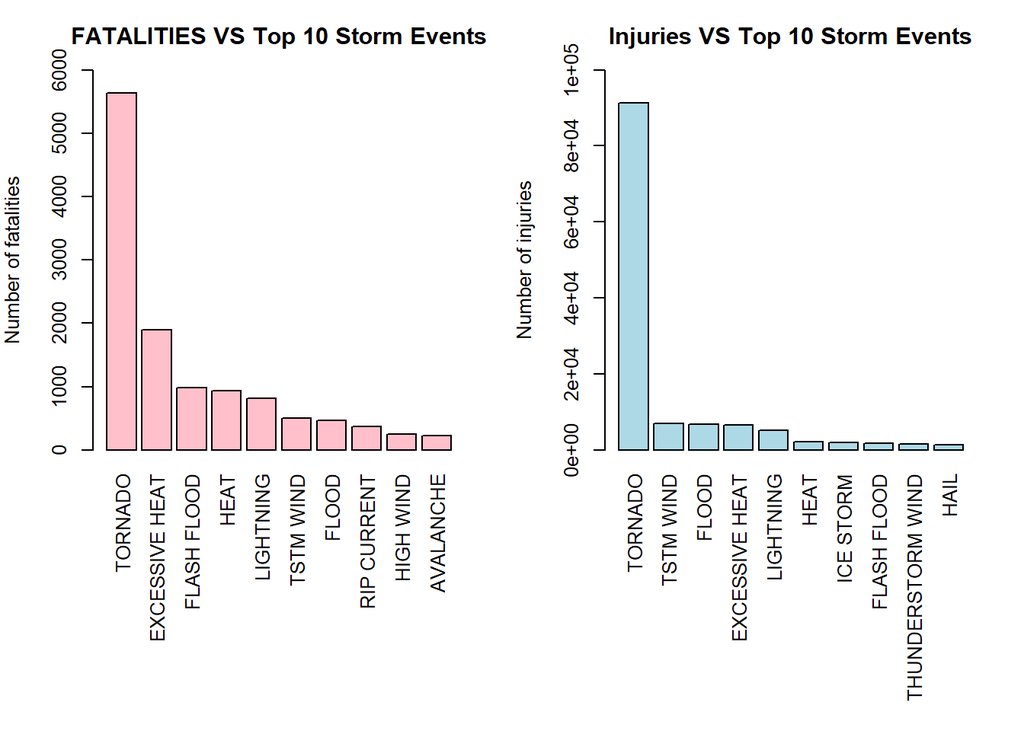

```r
par(mfrow = c(1, 2), mar = c(12, 4, 3, 2), mgp = c(3, 1, 0), cex = 0.8)
barplot(Storm_Fatal$FATALITIES, las = 3, names.arg = Storm_Fatal$EVTYPE, main = "FATALITIES VS Top 10 Storm Events",
        ylab = "Number of fatalities", col = "Pink", ylim = c(0,6000))
barplot(Storm_Injury$INJURIES, las = 3, names.arg = Storm_Injury$EVTYPE, main = "Injuries VS Top 10 Storm Events",
        ylab = "Number of injuries", col = "light blue", ylim = c(0,100000))
```

### This plot describe the Top 10 Storm Event with Hightest fatalities and injuries:

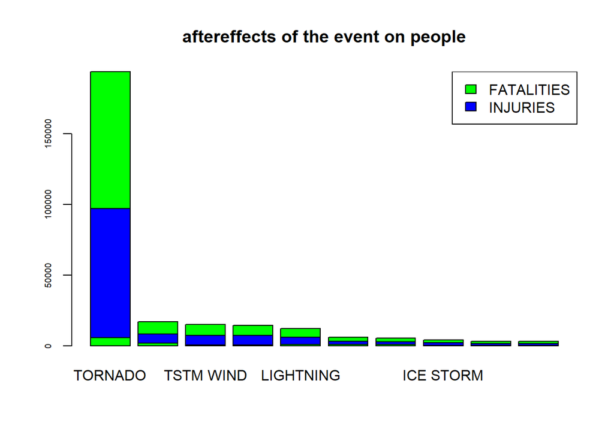

```r
barplot(health, col = c("green","blue"), main = "aftereffects of the event on people", cex.axis = 0.6)
legend("topright", c("FATALITIES","INJURIES"), fill = c("green","blue"))
```

### **Conclusion**

Looking from both aspects in Barplots it can be concluded that TORNADO has the hightest level of both Injuries and Fatalities, that causes most population health harms

## **2) Across the United States, which types of events have the greatest economic consequences?**

## **Data Processing**

From the entire data only selecting the relevant data need to answer this question.

```r
Storm_Property <- Storm[ , c(8,25:28)]
head(Storm_Property)
```

```
##    EVTYPE PROPDMG PROPDMGEXP CROPDMG CROPDMGEXP
## 1 TORNADO    25.0          K       0
## 2 TORNADO     2.5          K       0
## 3 TORNADO    25.0          K       0
## 4 TORNADO     2.5          K       0
## 5 TORNADO     2.5          K       0
## 6 TORNADO     2.5          K       0
```

### Our new data set includes:

1. Event Types (EVTYPE),
2. Property Damage (PROPDMG),
3. Property Damage Expense by symbol (PROPDAMAGE)
4. Crop Damage (CROPDMG)
5. Crop Damage Expense by symbol (CROPDAMAGE)

```r
head(Storm_Property)
```

```
##    EVTYPE PROPDMG PROPDMGEXP CROPDMG CROPDMGEXP
## 1 TORNADO    25.0          K       0
## 2 TORNADO     2.5          K       0
## 3 TORNADO    25.0          K       0
## 4 TORNADO     2.5          K       0
## 5 TORNADO     2.5          K       0
## 6 TORNADO     2.5          K       0
```

```r
colnames(Storm_Property)
```

```
## [1] "EVTYPE"     "PROPDMG"    "PROPDMGEXP" "CROPDMG"    "CROPDMGEXP"
```

### **Data looks a lot better now! We will now convert the PROPDMGEXP & CROPDMGEXP fields to tangible numbers where H (hundreds = 10^2), K (thousands = 10^3),M (millions = 10^6), and B (billions = 10^9) based on Wikipedia power of 10 table.**

```r
Storm_Property$PROPDMGEXP <- gsub("[Hh]", "2", Storm_Property$PROPDMGEXP)
Storm_Property$PROPDMGEXP <- gsub("[Kk]", "3", Storm_Property$PROPDMGEXP)
Storm_Property$PROPDMGEXP <- gsub("[Mm]", "6", Storm_Property$PROPDMGEXP)
Storm_Property$PROPDMGEXP <- gsub("[Bb]", "9", Storm_Property$PROPDMGEXP)
Storm_Property$PROPDMGEXP <- gsub("\\+", "1", Storm_Property$PROPDMGEXP)
Storm_Property$PROPDMGEXP <- gsub("\\?|\\-|\\ ", "0",  Storm_Property$PROPDMGEXP)
Storm_Property$PROPDMGEXP <- as.numeric(Storm_Property$PROPDMGEXP)

tail(Storm_Property)
```

```
##                EVTYPE PROPDMG PROPDMGEXP CROPDMG CROPDMGEXP
## 902292 WINTER WEATHER       0          3       0          K
## 902293      HIGH WIND       0          3       0          K
## 902294      HIGH WIND       0          3       0          K
## 902295      HIGH WIND       0          3       0          K
## 902296       BLIZZARD       0          3       0          K
## 902297     HEAVY SNOW       0          3       0          K
```

```r
Storm_Property$CROPDMGEXP <- gsub("[Hh]", "2", Storm_Property$CROPDMGEXP)
Storm_Property$CROPDMGEXP <- gsub("[Kk]", "3", Storm_Property$CROPDMGEXP)
Storm_Property$CROPDMGEXP <- gsub("[Mm]", "6", Storm_Property$CROPDMGEXP)
Storm_Property$CROPDMGEXP <- gsub("[Bb]", "9", Storm_Property$CROPDMGEXP)
Storm_Property$CROPDMGEXP <- gsub("\\+", "1", Storm_Property$CROPDMGEXP)
Storm_Property$CROPDMGEXP <- gsub("\\-|\\?|\\ ", "0", Storm_Property$CROPDMGEXP)
Storm_Property$CROPDMGEXP <- as.numeric(Storm_Property$CROPDMGEXP)

Storm_Property$PROPDMGEXP[is.na(Storm_Property$PROPDMGEXP)] <- 0
Storm_Property$CROPDMGEXP[is.na(Storm_Property$CROPDMGEXP)] <- 0

Storm_Property <- mutate(Storm_Property,
                    PROPDMGTOTAL = PROPDMG * (10 ^ PROPDMGEXP),
                    CROPDMGTOTAL = CROPDMG * (10 ^ CROPDMGEXP))
head(Storm_Property)
```

```
##    EVTYPE PROPDMG PROPDMGEXP CROPDMG CROPDMGEXP PROPDMGTOTAL CROPDMGTOTAL
## 1 TORNADO    25.0          3       0          0        25000            0
## 2 TORNADO     2.5          3       0          0         2500            0
## 3 TORNADO    25.0          3       0          0        25000            0
## 4 TORNADO     2.5          3       0          0         2500            0
## 5 TORNADO     2.5          3       0          0         2500            0
## 6 TORNADO     2.5          3       0          0         2500            0
```

### Part 1: Here the Property Damage and Crop Damage are considered Separately:

### **Processing the data related to property damage occurred by Storm:**

```r
St_PROPDMG <- aggregate(PROPDMGTOTAL ~ EVTYPE, data = Storm_Property, FUN = sum)
head(St_PROPDMG)
```

```
##                  EVTYPE PROPDMGTOTAL
## 1    HIGH SURF ADVISORY       200000
## 2         COASTAL FLOOD            0
## 3           FLASH FLOOD        50000
## 4             LIGHTNING            0
## 5             TSTM WIND      8100000
## 6       TSTM WIND (G45)         8000
```

```r
St_PROPDMG <- St_PROPDMG[order(St_PROPDMG$PROPDMGTOTAL, decreasing = TRUE), ]
head(St_PROPDMG)
```

```
##                EVTYPE PROPDMGTOTAL
## 170             FLOOD 144657709807
## 411 HURRICANE/TYPHOON  69305840000
## 834           TORNADO  56947381217
## 670       STORM SURGE  43323536000
## 153       FLASH FLOOD  16822673979
## 244              HAIL  15735267513
```

```r
## aranging the data and taking top 10 enteries
St_PROP <- St_PROPDMG[1:10, ]
St_PROP
```

```
##                EVTYPE PROPDMGTOTAL
## 170             FLOOD 144657709807
## 411 HURRICANE/TYPHOON  69305840000
## 834           TORNADO  56947381217
## 670       STORM SURGE  43323536000
## 153       FLASH FLOOD  16822673979
## 244              HAIL  15735267513
## 402         HURRICANE  11868319010
## 848    TROPICAL STORM   7703890550
## 972      WINTER STORM   6688497251
## 359         HIGH WIND   5270046475
```

### **Processing the data related to the Crop Damage occurred by Storm events**

```r
St_CROPDMG <- aggregate(CROPDMGTOTAL ~ EVTYPE, data = Storm_Property, FUN = sum)
St_CROPDMG <- St_CROPDMG[order(St_CROPDMG$CROPDMGTOTAL, decreasing = TRUE), ]
head(St_CROPDMG)
```

```
##          EVTYPE CROPDMGTOTAL
## 95      DROUGHT  13972566000
## 170       FLOOD   5661968450
## 590 RIVER FLOOD   5029459000
## 427   ICE STORM   5022113500
## 244        HAIL   3025954473
## 402   HURRICANE   2741910000
```

```r
St_CROP <- St_CROPDMG[1:10, ]
```

## Part 2: Senario where property and Crop damage considered together.

```r
St_Both <- aggregate(cbind(PROPDMGTOTAL, CROPDMGTOTAL) ~ EVTYPE, data = Storm_Property, FUN = sum)
head(St_Both)
```

```
##                  EVTYPE PROPDMGTOTAL CROPDMGTOTAL
## 1    HIGH SURF ADVISORY       200000            0
## 2         COASTAL FLOOD            0            0
## 3           FLASH FLOOD        50000            0
## 4             LIGHTNING            0            0
## 5             TSTM WIND      8100000            0
## 6       TSTM WIND (G45)         8000            0
```

```r
St_Both$Economic <- St_Both$PROPDMGTOTAL + St_Both$CROPDMGTOTAL
St_Both <- St_Both[order(St_Both$Economic, decreasing = TRUE), ]
St_BOTH <- St_Both[1:10, ]
St_BOTH
```

```
##                EVTYPE PROPDMGTOTAL CROPDMGTOTAL     Economic
## 170             FLOOD 144657709807   5661968450 150319678257
## 411 HURRICANE/TYPHOON  69305840000   2607872800  71913712800
## 834           TORNADO  56947381217    414953270  57362334487
## 670       STORM SURGE  43323536000         5000  43323541000
## 244              HAIL  15735267513   3025954473  18761221986
## 153       FLASH FLOOD  16822673979   1421317100  18243991079
## 95            DROUGHT   1046106000  13972566000  15018672000
## 402         HURRICANE  11868319010   2741910000  14610229010
## 590       RIVER FLOOD   5118945500   5029459000  10148404500
## 427         ICE STORM   3944927860   5022113500   8967041360
```

## **Result**

The analysis covers the Economic damage done to property and Crops by the Storm. The bargraph is presented for visualtion purposes which shows the adverse effects of Storm.

Part 1: The Plot shows the Property Damage and Crop Damage Separately:

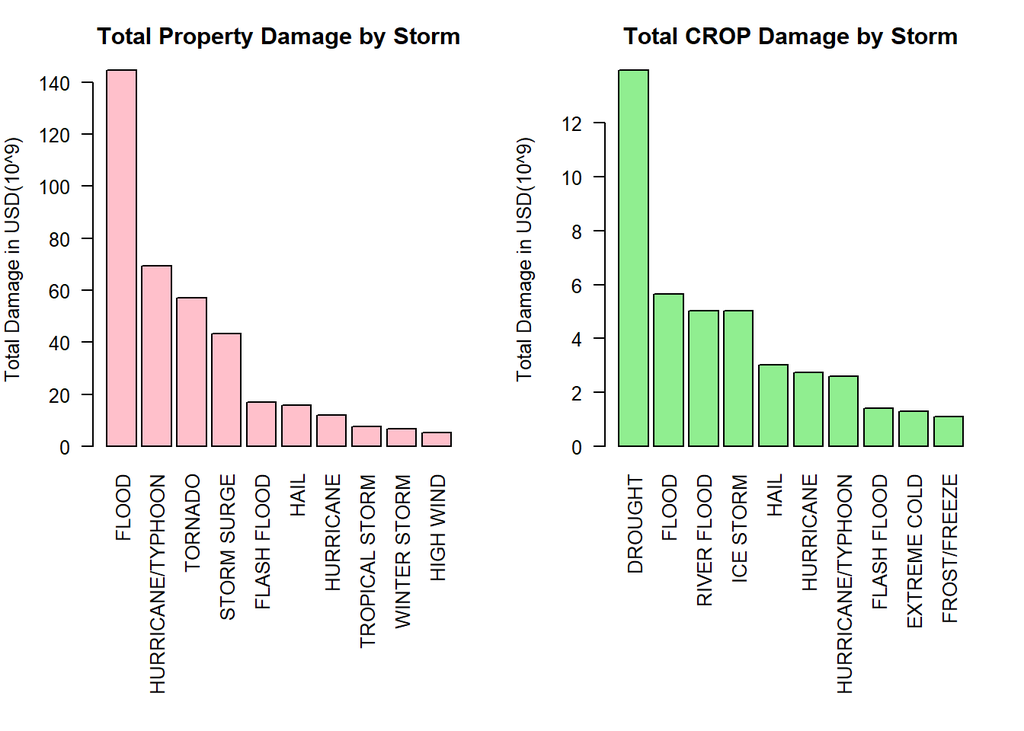

```r
par(mfrow = c(1, 2), mar = c(12, 4, 3, 2), mgp = c(3, 1, 0), cex = 0.8)
barplot(St_PROP$PROPDMGTOTAL/10^9, names.arg = St_PROP$EVTYPE, col = "pink", las = 2, main = "Total Property Damage by Storm",
        ylab = "Total Damage in USD(10^9)")
barplot(St_CROP$CROPDMGTOTAL/10^9, names.arg = St_CROP$EVTYPE, col = "light green", las = 2, main = "Total CROP Damage by Storm",
        ylab = "Total Damage in USD(10^9)")
```

Part:2 Here the Plot shows the combined result of the property and Crop damage by the Storm Events:

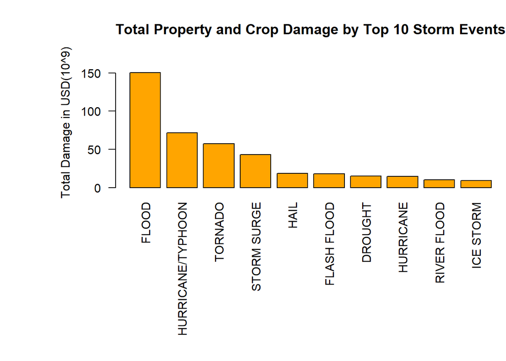

```r
par(mfrow= c(1,1), mar = c(12,8,4,0))
barplot(St_BOTH$Economic/10^9, names.arg = St_BOTH$EVTYPE, col = "orange",
        las = 2, main = "Total Property and Crop Damage by Top 10 Storm Events",
        ylim = c(0,170), ylab = "Total Damage in USD(10^9)")
```

## **RESULTS**

[output not shown]